# Assignment 2

Eric D’Souza

February 4th,2020

**Loading required libraries**

```r
library(fpp2)
library(knitr)
```

**Loading required library for “PAYSNA” dataset**

```r
library(quantmod)
symbols <- c("PAYNSA")
m = length(symbols)
getSymbols (symbols,src="FRED")
```

[output not shown]

```
## [1] "PAYNSA"
```

```r
#converting to dataframe
df_n = ts(PAYNSA, start=1939, frequency=12)
p = df_n[,"PAYNSA"]

#Made an adhjustment for Question c) to add continiutiy for the forecast
timeperiod <- window(p,start=c(2010,1))

#Using only required dataset
z = window(p,start=c(2010, 1),end=c(2017, 12))
View(z)
```

[output not shown]

*Please note for above. The error is displayed on the HTML format becuase of a certain package. The table is other wise viewable in rstudio.

**Part A**

```r
TS_P <- tslm(z ~ trend+season)
summary(TS_P)
```

```
##
## Call:
## tslm(formula = z ~ trend + season)
##
## Residuals:
##     Min      1Q  Median      3Q     Max
## -714.04 -340.30    2.14  238.43 1307.75
##
## Coefficients:
##              Estimate Std. Error t value Pr(>|t|)
## (Intercept) 1.263e+05  1.716e+02 736.130  < 2e-16 ***
## trend       1.999e+02  1.642e+00 121.759  < 2e-16 ***
## season2     6.346e+02  2.212e+02   2.869  0.00522 **
## season3     1.273e+03  2.212e+02   5.755 1.41e-07 ***
## season4     2.157e+03  2.212e+02   9.749 2.08e-15 ***
## season5     2.813e+03  2.213e+02  12.712  < 2e-16 ***
## season6     3.079e+03  2.213e+02  13.911  < 2e-16 ***
## season7     1.741e+03  2.214e+02   7.863 1.22e-11 ***
## season8     1.828e+03  2.215e+02   8.255 2.02e-12 ***
## season9     2.225e+03  2.216e+02  10.042 5.42e-16 ***
## season10    2.995e+03  2.217e+02  13.512  < 2e-16 ***
## season11    3.226e+03  2.218e+02  14.547  < 2e-16 ***
## season12    2.867e+03  2.219e+02  12.919  < 2e-16 ***
## ---
## Signif. codes:  0 '***' 0.001 '**' 0.01 '*' 0.05 '.' 0.1 ' ' 1
##
## Residual standard error: 442.3 on 83 degrees of freedom
## Multiple R-squared:  0.9949, Adjusted R-squared:  0.9941
## F-statistic:  1337 on 12 and 83 DF,  p-value: < 2.2e-16
```

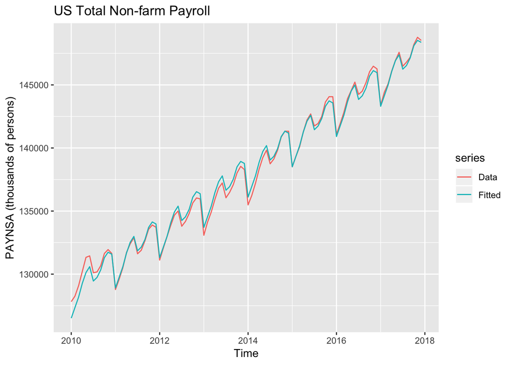

```r
autoplot(z, series = "Data") +
  autolayer(fitted(TS_P), series = "Fitted") +
  ylab("PAYNSA (thousands of persons)") + ggtitle("US Total Non-farm Payroll")
```

**Scatterplot representation of data points for the actual values and the fitted values for PAYNSA**

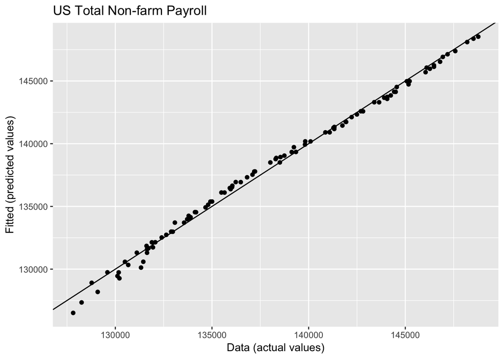

```r
cbind(Data = z,
      Fitted = fitted(TS_P)) %>%
  as.data.frame() %>%
  ggplot(aes(x=Data, y=Fitted)) +
    geom_point() +
    ylab("Fitted (predicted values)") +
    xlab("Data (actual values)") +
    ggtitle("US Total Non-farm Payroll") +
    geom_abline(intercept=0, slope=1)
```

**Checking Residuals and analysis for the same**

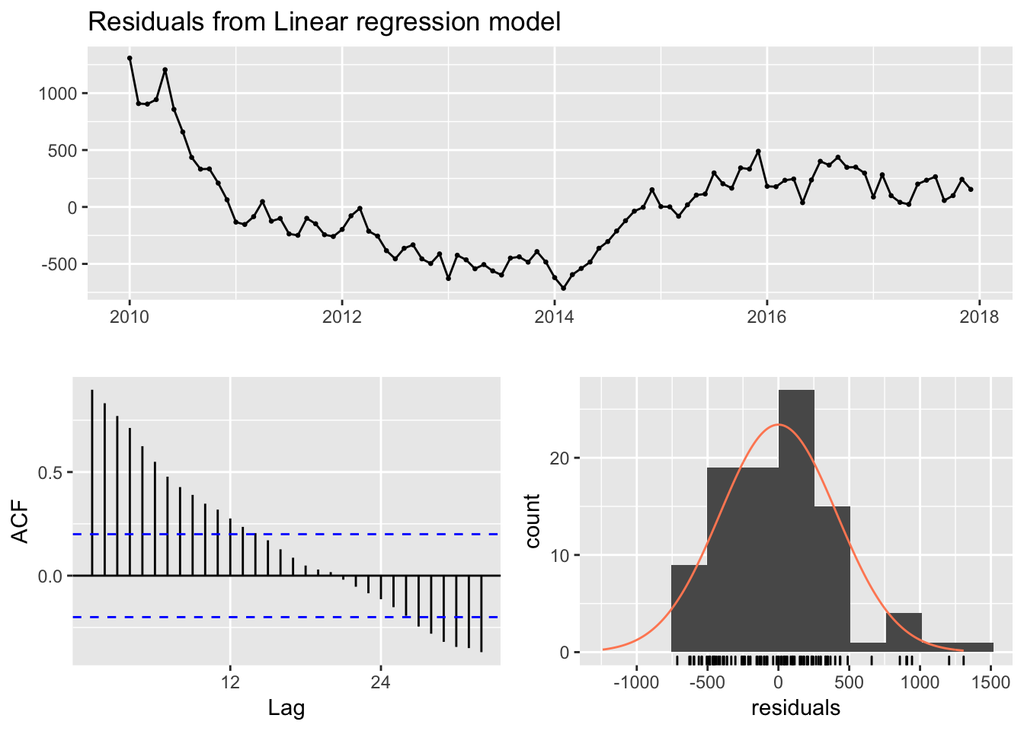

```
##
##  Breusch-Godfrey test for serial correlation of order up to 19
##
## data:  Residuals from Linear regression model
## LM test = 79.123, df = 19, p-value = 2.633e-09
```

```r
checkresiduals(TS_P)
```

In order to determine how well the model fits, I first created a time series plot with the fitted values layered over the actual data provided by the dataset. Based of the plotted graph, it is clear that the model fits relatively well, but is seemingly being impacted by some discrepancy from 2010, and 2013-2014.

For the scatterplot, I would say most of the data is near the regression line, indicating that the fitted data has accurately captured the actual data. Several points are being noticed as an anomaly near the left tail end and the middle which is a reflection of what was described in the time series graph.

Finally, using the summary() function, we can see that the R^2 value is 99%, which indicates a very good fit as the value is close to 1. P-value is equal to 0.00000000000000022, which is statsistically significant.

For the residual analysis. The time series plot resmebles the scatterplot information above. Which is in line with the analyssi i had made for the scatterplot graph. The ACF plot has a downward trend, which is indicated by the constant decrease with the increase in lag.There is not storng seasonal factor for the same. Finally, the histogram is slightly skewed to the right, with an anomaly aorund the 250 residual mark.

———-END OF QUESITON A——————–

**————START OF QUESTION B——————-**

```r
#I have used a for loop to avoid repetition of  inserting multiple lines of code
for (h in 1:6) {
  fourier_P = tslm(z ~ trend + fourier(z, K = h))
  print(CV(fourier_P))
}
```

```
##           CV          AIC         AICc          BIC        AdjR2
## 9.780843e+05 1.325990e+03 1.326657e+03 1.338812e+03 9.717855e-01
##           CV          AIC         AICc          BIC        AdjR2
## 3.463712e+05 1.225904e+03 1.227176e+03 1.243854e+03 9.902470e-01
##           CV          AIC         AICc          BIC        AdjR2
## 3.383269e+05 1.223287e+03 1.225380e+03 1.246366e+03 9.906897e-01
##           CV          AIC         AICc          BIC        AdjR2
## 2.683682e+05 1.200432e+03 1.203575e+03 1.228640e+03 9.927979e-01
##           CV          AIC         AICc          BIC        AdjR2
## 2.696430e+05 1.200312e+03 1.204751e+03 1.233648e+03 9.929362e-01
##           CV          AIC         AICc          BIC        AdjR2
## 2.279336e+05 1.183711e+03 1.188896e+03 1.219611e+03 9.941103e-01
```

For the above lines of code, we have set a harmonic regressions. The highest possible fourier term is 6 based off of the formula, K=M/2 (M is the number of seasonal periods), we have 12 seasonal periods, therefore the highest K value that could be tested and run was 6. I ran a for loop through the code, to avoid the clutter. After analysis, K6 had the lowest AIC and CV scores.

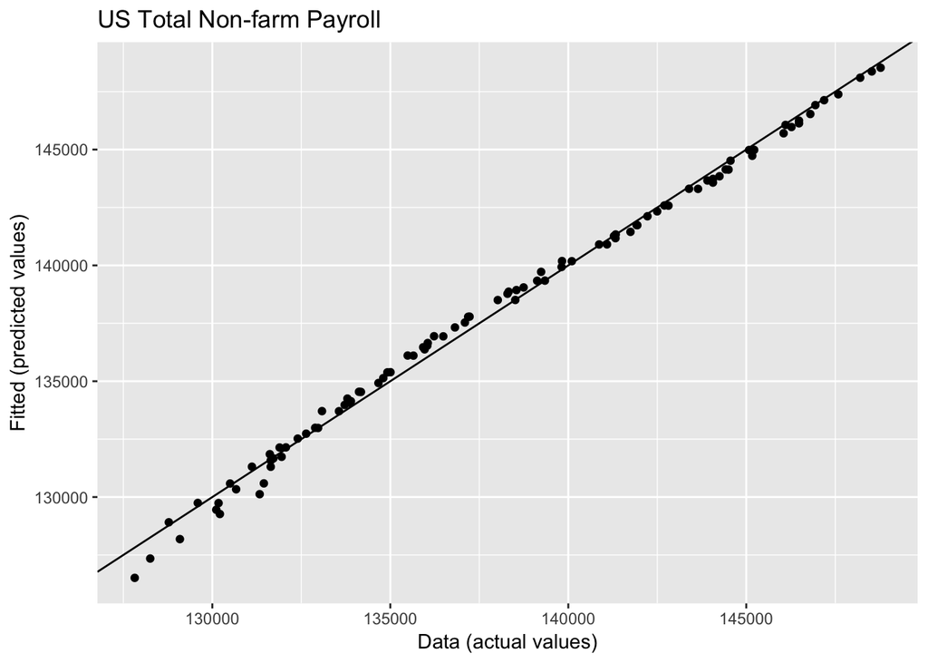

```r
#Runnning the harmonic regression, 6 variables have proved to have the lowest CV values. The appropriate number of fourier terms for our case is 6
fourier_PA = tslm(z ~ trend + fourier(z, K = 6))

cbind(Data = z,
      Fitted = fitted(fourier_PA)) %>%
  as.data.frame() %>%
  ggplot(aes(x=Data, y=Fitted)) +
    geom_point() +
    ylab("Fitted (predicted values)") +
    xlab("Data (actual values)") +
    ggtitle("US Total Non-farm Payroll") +
    geom_abline(intercept=0, slope=1)
```

```r
summary(fourier_PA)
```

```
##
## Call:
## tslm(formula = z ~ trend + fourier(z, K = 6))
##
## Residuals:
##     Min      1Q  Median      3Q     Max
## -714.04 -340.30    2.14  238.43 1307.75
##
## Coefficients:
##                          Estimate Std. Error  t value Pr(>|t|)
## (Intercept)            128382.142     91.541 1402.448  < 2e-16 ***
## trend                     199.923      1.642  121.759  < 2e-16 ***
## fourier(z, K = 6)S1-12   -631.460     64.140   -9.845 1.34e-15 ***
## fourier(z, K = 6)C1-12   -256.495     63.867   -4.016 0.000129 ***
## fourier(z, K = 6)S2-12  -1008.513     63.910  -15.780  < 2e-16 ***
## fourier(z, K = 6)C2-12    421.682     63.867    6.602 3.59e-09 ***
## fourier(z, K = 6)S3-12   -200.369     63.867   -3.137 0.002360 **
## fourier(z, K = 6)C3-12     23.890     63.867    0.374 0.709317
## fourier(z, K = 6)S4-12   -232.248     63.853   -3.637 0.000477 ***
## fourier(z, K = 6)C4-12    291.098     63.867    4.558 1.76e-05 ***
## fourier(z, K = 6)S5-12    -44.892     63.848   -0.703 0.483955
## fourier(z, K = 6)C5-12    126.649     63.867    1.983 0.050674 .
## fourier(z, K = 6)C6-12    190.216     45.154    4.213 6.38e-05 ***
## ---
## Signif. codes:  0 '***' 0.001 '**' 0.01 '*' 0.05 '.' 0.1 ' ' 1
##
## Residual standard error: 442.3 on 83 degrees of freedom
## Multiple R-squared:  0.9949, Adjusted R-squared:  0.9941
## F-statistic:  1337 on 12 and 83 DF,  p-value: < 2.2e-16
```

Running the harmonic regression 6-K values , K=6 had the lowest AIC and CV scores, and thus we conducted the rest of the analysis with fourier.When comparing our linear model (TSLM) and harmonic model, the results and data appear to fit the same with resmebling anomalies of data points being off the left tail end and the middle.After running the summary function, I noted that there was the same multiple r-squared and p-value. I can conclude that there is no difference between the TSLM and Harmonic model in this section. I expected a slight chnage if anything with the harmoninc model considering the added varibales. But, as the texbook indiciated, the increase in varibales doesnt necassirly change R^2 value.

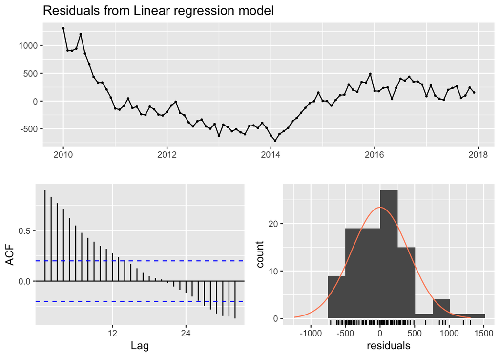

```
##
##  Breusch-Godfrey test for serial correlation of order up to 19
##
## data:  Residuals from Linear regression model
## LM test = 79.123, df = 19, p-value = 2.633e-09
```

```r
checkresiduals(fourier_PA)
```

I should not be too surprised by the the outcome of the checkresiduals function,the above- Time plot, ACF graph and the residual graph appear to be the same, as the TSLM residuals. The values of R^2 and p-value are the same with a slight change in percentage numbers.Hence shape and trend factors resemble both in the TSLM and harmonic regression analysis.

—————End of Question B———————-

**—————-START OF QUESTION C———————-**

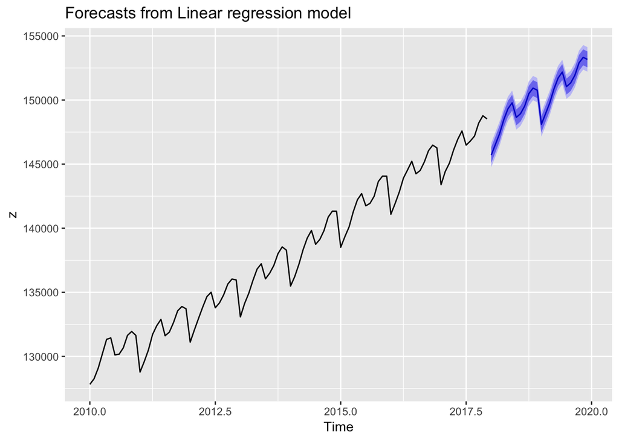

```r
#Forecast for PAYNSA series for each each mehtod and the choosen variables
fc_1 = forecast(TS_P, h=24)
autoplot(fc_1)
```

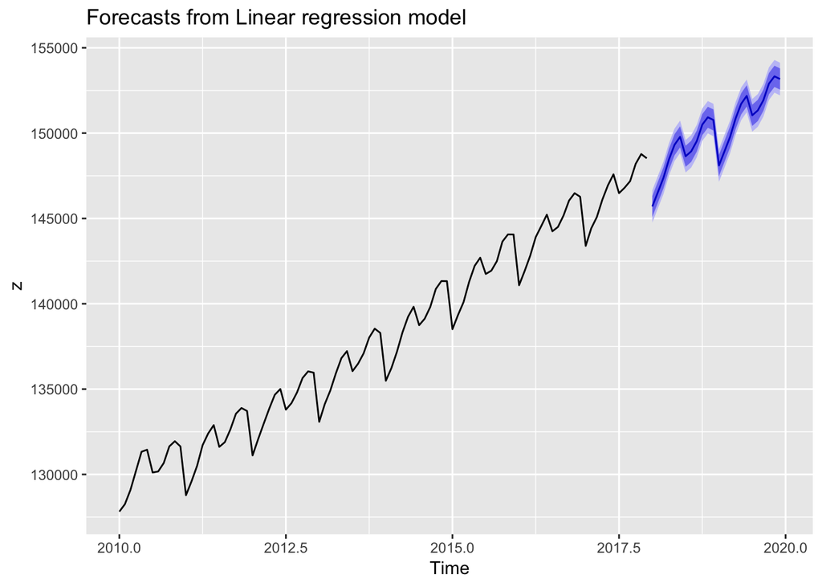

```r
fc_2 = forecast(fourier_PA, newdata = data.frame(fourier(z, 6, 24)))
autoplot(fc_2)
```

```r
accuracy(fc_1)
```

```
##                         ME     RMSE      MAE           MPE      MAPE
## Training set -9.094947e-13 411.3011 323.6508 -0.0005866758 0.2377726
##                   MASE      ACF1
## Training set 0.1393102 0.8970761
```

```r
accuracy(fc_2)
```

```
##                         ME     RMSE      MAE           MPE      MAPE
## Training set -1.516573e-13 411.3011 323.6508 -0.0005866758 0.2377726
##                   MASE      ACF1
## Training set 0.1393102 0.8970761
```

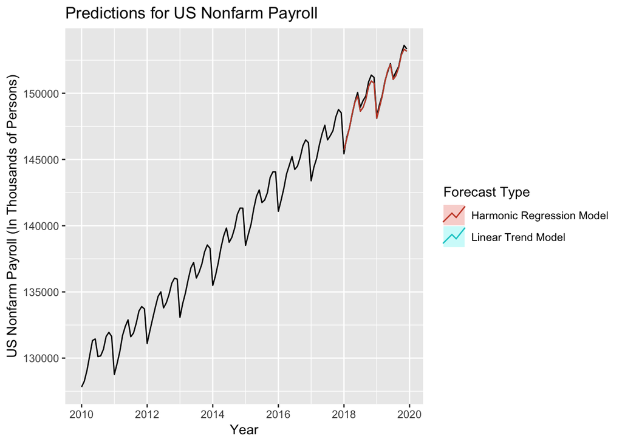

```r
autoplot(timeperiod) +
  ylab("US Nonfarm Payroll (In Thousands of Persons)") +
  xlab("Year") +
  ggtitle("Predictions for US Nonfarm Payroll") +
  autolayer(fc_1, PI = FALSE, series = "Linear Trend Model") +
  autolayer(fc_2, PI = FALSE, series = "Harmonic Regression Model") +
  guides(colour = guide_legend(title = "Forecast Type"))
```